# TIER: Activity 2

Simon Halliday

9 January 2017

Exercise

1. What was the mean number of people named Carmel in the sample? Use the function `favstats()` with the variable name “yearlytotal” and the data table “Carmel” to find out. Round to the nearest unit.
2. In what year was the name Carmel first used for females? In what year was the name Carmel first used for males?
3. What are the dimensions of the object (data table/data frame) `FemCarmel`?
4. How many women named Carmel were born in 1980?
5. What happens when you substitute in your name for the name Lesley in the plot?

Install the packages we require: `devtools`, `mosaic`, and `DataComputing`. You’ll need to *uncomment* the lines below by deleting the hashtag `#`.

```r
#install.packages("mosaic")
#install.packages("devtools")
#devtools::install_github("DataComputing/DataComputing")
library(DataComputing)
library(mosaicData)
library(mosaic)
```

I picked a name randomly from the workshop and got “Carmel”. We shall investigate a little bit about that name using the `BabyNames` datatable provided in `DataComputing`.

I ran the following command to create a data table called `Carmel` to provide a table with the total of all people called Carmel in the `BabyNames` data table.

Copy and paste this command into your console or R markdown in a data chunk and run it.

```r
Carmel <-
  BabyNames %>%
  filter(name == "Carmel") %>%
  group_by(year, sex) %>%
  summarise(yearlytotal = sum(count))
```

You should now have an object in your “Environment” tab called “Carmel”.

### head()

For the question in the quiz, you need to use the function `head()` to find out how many people are called Carmel at the top of the data table Carmel.

```r
head(Carmel)
```

[output not shown]

### favstats()

Run the `favstats()` function to find the summary statistics of the variable `yearlytotal` with the data table `Carmel`.

What is the mean value of `yearlytotal` rounded to the closest unit? What was the maximum number of people called Carmel in one year? Do you think you could work out what year that was in? (perhaps not, but think about that again after the next sub-section.)

### dim() of FemCarmel

For the next part of the activity you need to find out the dimensions of your DataTable. To find out the dimensions of a data table we use the function `dim()`:

```r
dim(FemCarmel)
```

[output not shown]

### FemCarmel1980

Display your total in the console (or in your knitted R markdown) calling on the data table’s name:

```r
FemCarmel1980
```

[output not shown]

### Final Aside

Note, you could also have just typed `View(FemCarmel)` in the console and scrolled until you got to 1980 to check how many women named Carmel were born in that year, rather than creating a new object. But creating a new object is good practise for things yet to come.

### Bonus Graphic: Lesley over time

Let’s move away from Carmel and pick another person’s name from the workshop, “Lesley”. We can see how the totals of males and females named Lesley has changed over time.

The code below shows what we’d need to do to get the data for the name Lesley and then put it into a `ggplot` (grammar of graphics plot). Also, if you want to, you can substitute each instance of the name “Lesley” in the code chunk for a name that you want to investigate to see what has happened to that name over time (e.g. your own). You’ll notice that some names are *never* used for males and some names are *never* used for females try names from people in the workshop to see what I mean.

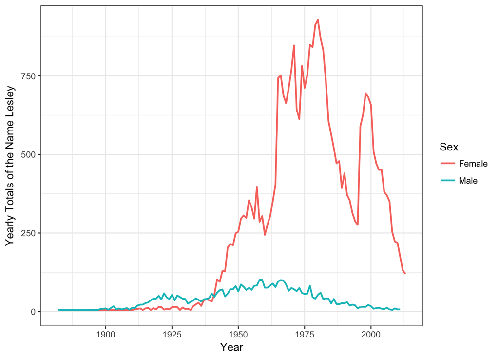

```r
Lesley <-
  BabyNames %>%
  filter(name == "Lesley") %>%
  group_by(year, sex) %>%
  summarise(yearlytotal = sum(count))
Lesley %>%
  ggplot(aes(x = year, y = yearlytotal, color = sex)) +
  geom_line(size = 0.8) +
  ylim(0, NA) +
  ylab("Yearly Totals of the Name Lesley") +
  xlab("Year") +
  scale_color_discrete(name="Sex",
                         breaks=c("F", "M"),
                         labels=c("Female", "Male")) +
  theme_bw()
```